# Assignment2

Jonathan Marin

January 18, 2018

# Question 1

## What is the Basic workflow for reproducible research?

- Data Gathering
- Data Analysis
- Results Representation

## What are five practical tips for making research reproducible?

- Document everything
- Everything is a text file
- All files should be human readable
- Explicity tie your files together
- Have a plan to organize, store, and make your files available

## Give an example of how you might implement each tip.

- Document everything ~ Example: Make sure to keep track of R Version as they update every 6 months
- Everything is a text file ~ Text files (.txt) are nimble and won’t stop working with new versions of other applications
- All files should be human readable ~ Treat all research files as if someone who has not worked on the project can understand it and use comments in code
- Explicity tie your files together ~ Files have relationships between each other and should be documented
- Have a plan to organize, store, and make your files available ~ Files need to be orgazined and object oriented as possible and should be modular.

## Which one of these do you think will be the most difficult?

This is tough. I think documenting everything is the most difficult for me. Often times, I can go off and write working code for hours without a entering a single line of comments because I know what it is doing and at work, people don’t question my code or sql that often enough to need to see the comments. If so, I can explain it. Getting used to putting that in so that the code isn’t dependent on me will be a big change.

# Question 2

```r
knitr::opts_chunk$set(echo = TRUE)

###################################################################################
# air_hist.R - Unit 2 Live Session Homework
###################################################################################
# Note: Please reformat these to place into your RMarkdown submission document.
# You can make sure it works here, but make it easy for your grader via RMD
###################################################################################

# You are responsible for the TODOs, but the complete code here will give you
# an idea of what the data look like.  Remember, you might need some of this code
# directly in your response file to make it work, even if it's not TODO!!

# We will be using the built-in dataset airquality which has daily air quality
# measurements in New York from May to September 1973
str(airquality)
```

```
## 'data.frame':    153 obs. of  6 variables:
##  $ Ozone  : int  41 36 12 18 NA 28 23 19 8 NA ...
##  $ Solar.R: int  190 118 149 313 NA NA 299 99 19 194 ...
##  $ Wind   : num  7.4 8 12.6 11.5 14.3 14.9 8.6 13.8 20.1 8.6 ...
##  $ Temp   : int  67 72 74 62 56 66 65 59 61 69 ...
##  $ Month  : int  5 5 5 5 5 5 5 5 5 5 ...
##  $ Day    : int  1 2 3 4 5 6 7 8 9 10 ...
```

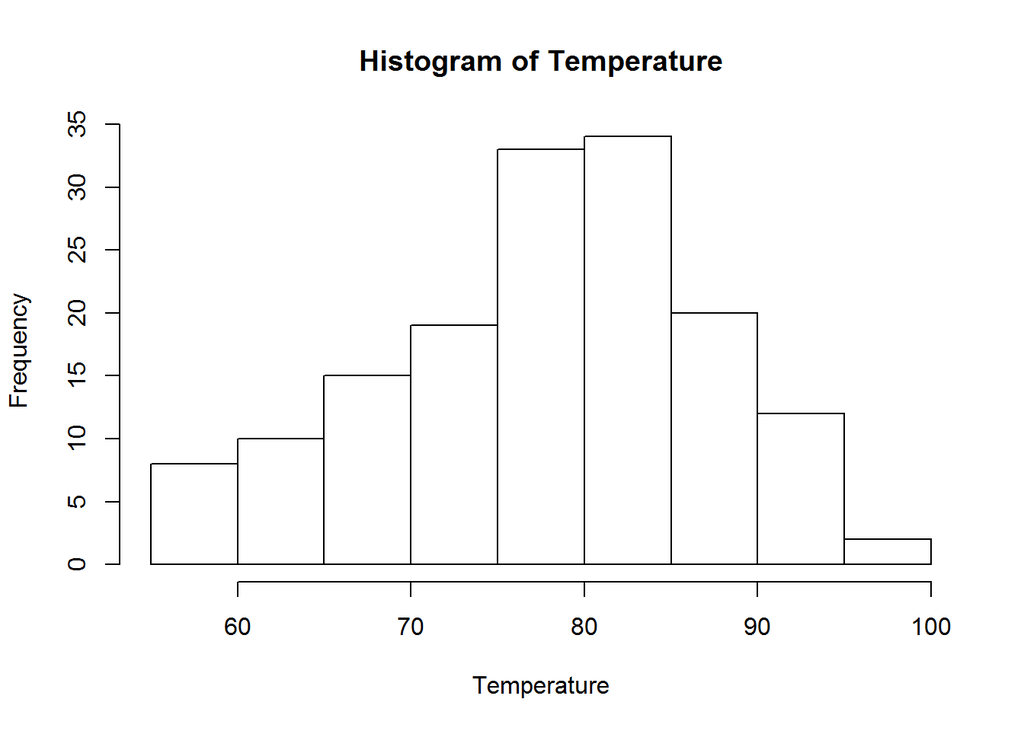

```r
# Take only Temp columns
Temperature <- airquality$Temp
hist(Temperature)
```

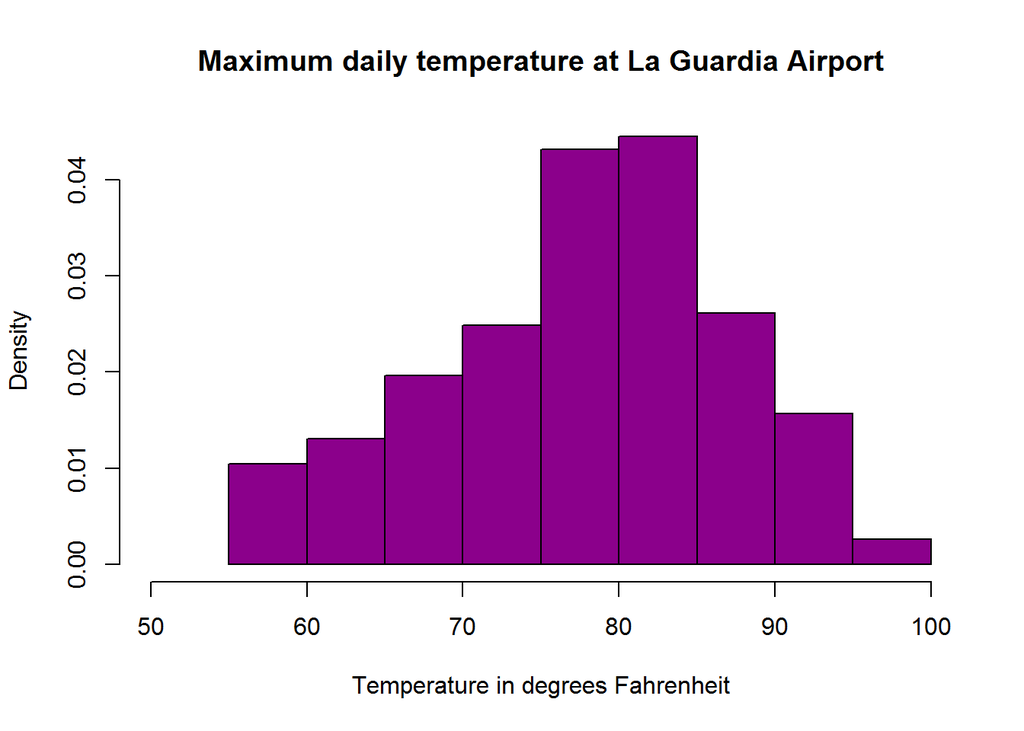

```r
# Histogram with added parameters
hist(Temperature,
     main="Maximum daily temperature at La Guardia Airport",
     xlab="Temperature in degrees Fahrenheit",
     xlim=c(50,100),
     col="darkmagenta",
     freq=FALSE
)
```

## Q2A

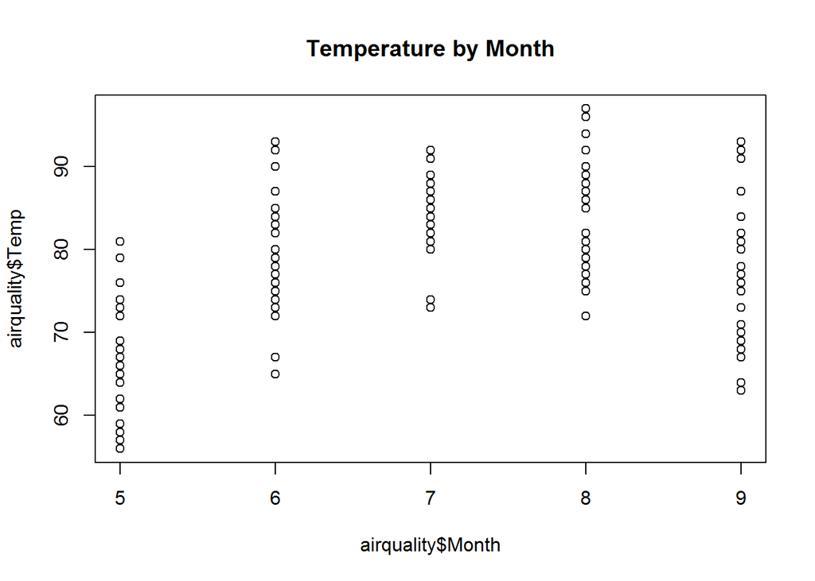

```r
# TODO: Assignment 2, Q2A: Complete the following code to yield a scatterplot with x as Month and y as Temp
# You're going to customize your plot slightly.  Use the help function to assist you if needed.
# Make the x label "Month" and the y label "Temperature"
# Finally, make the title of the plot "Temperature by Month"
plot(x=airquality$Month, y=airquality$Temp, main = "Temperature by Month")
```

## Q2b

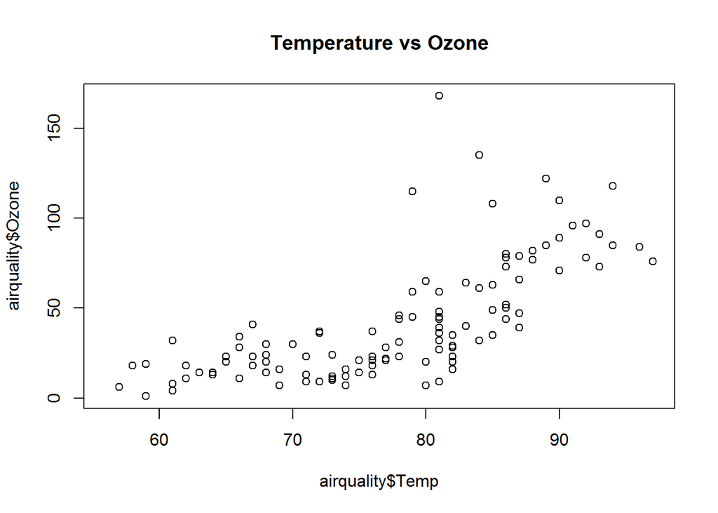

```r
# TODO: Assignment 2, Q2B: Build a scatter plot with x as Temperature and y as Ozone
# Complete the following code:
# Make the x label "Temperature" and the y label "Ozone",
# Make the title of the plot "Temperature vs Ozone"
plot(x=airquality$Temp, y=airquality$Ozone, main = "Temperature vs Ozone")
```